# Assignment 2

## Task 2: Analysis

1. Use functions from base R to compute which month had in total the highest and the lowest Precipitation Amount.

```r
# base r aggregate function
df_rain <- aggregate(as.numeric(db_tib$rain), by=list(Category=db_tib$month), FUN=sum)
```

```r
# Highest precipitation amount
df_rain[which.max(df_rain$x),]
```

```
   Category     x
12     July 149.2
```

```r
# Lowest precipitation amount
df_rain[which.min(df_rain$x),]
```

```
  Category    x
7 February 16.2
```

```r
# Via dplyr in one shot
df_rain2 <- db_tib %>%
  group_by(month) %>%
  summarise(rain_sum = sum(as.numeric(rain))) %>%
  arrange(desc(rain_sum)) %>%
  filter(row_number()==1 | row_number()==n())

df_rain2
```

```
# A tibble: 2 × 2
  month    rain_sum
  <ord>       <dbl>
1 July        149.
2 February     16.2
```

2. Use ggplot2 to create a time series plot of the maximum and minimum daily temperatures. The two time series must be on the same plot.

```r
# Add maximum and minimum temperature columns
temps_df <- db_tib %>%
  group_by(day_of_week) %>%
  mutate(max_temp = max(temp), min_temp = min(temp))

temps_df
```

```
# A tibble: 8,727 × 17
# Groups:   day_of_week [7]
   Date       Hour     day_of_week month      rain  temp  wdsp clamt
   <date>     <chr>    <ord>       <ord>     <dbl> <dbl> <dbl> <ord>
 1 2022-08-31 00:00:00 Wednesday   August        0  13       6 6
 2 2022-09-01 01:00:00 Thursday    September     0  13.6     7 6
 3 2022-09-01 02:00:00 Thursday    September     0  14       6 6
 4 2022-09-01 03:00:00 Thursday    September     0  14.4     5 6
 5 2022-09-01 04:00:00 Thursday    September     0  14.4     5 7
 6 2022-09-01 05:00:00 Thursday    September     0  13.5     6 7
 7 2022-09-01 06:00:00 Thursday    September     0  14.2     6 7
 8 2022-09-01 07:00:00 Thursday    September     0  15       8 7
 9 2022-09-01 08:00:00 Thursday    September     0  15.5     9 7
10 2022-09-01 09:00:00 Thursday    September     0  16.4    11 5
# ℹ 8,717 more rows
# ℹ 9 more variables: `Clontarf - James Larkin Rd` <dbl>,
#   `Clontarf - Pebble Beach Carpark` <dbl>,
#   `Griffith Avenue (Clare Rd Side)` <dbl>,
#   `Griffith Avenue (Lane Side)` <dbl>, `Grove Road Totem` <dbl>,
#   `Richmond Street Cyclists 1` <dbl>, `Richmond Street Cyclists 2` <dbl>,
#   max_temp <dbl>, min_temp <dbl>
```

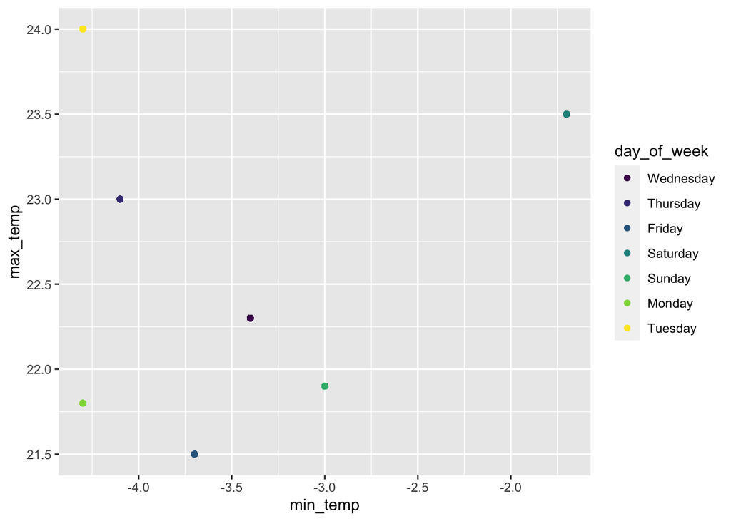

```r
# Create and display plot
library(ggplot2)
temps_plot <- ggplot(temps_df, aes(x = min_temp, y = max_temp, color = day_of_week))

temps_plot + geom_point()
```

3. Check if, according to this dataset, there has been on average more rain during the weekend (Sat-Sun) with respect to weekdays (Mon-Fri).

```r
# Create weekdays vector
weekdays_v <- c("Monday", "Tuesday", "Wednesday", "Thursday", "Friday")

# calculate rainfall for weekdays
rain_weekdays <- db_tib %>%
  group_by(day_of_week) %>%
  filter(day_of_week %in% weekdays_v) %>%
  summarise(weekdays_rainfall = sum(rain), weekdays_mean_rainfall = mean(rain))

# Initialize weekends vector
weekends_v <- c("Saturday", "Sunday")

# Calculate rainfall for weekends
rain_weekends <- db_tib %>%
  group_by(day_of_week) %>%
  filter(day_of_week %in% weekends_v) %>%
  summarise(weekends_rainfall = sum(rain), weekends_mean_rainfall = mean(rain))
```

```r
# Weekdays rainfall
sum(rain_weekdays$weekdays_rainfall)
```

```
[1] 597.3
```

```r
# Weekends rainfall
sum(rain_weekends$weekends_rainfall)
```

```
[1] 350.3
```

```r
# Check rain totals by comparing to original data set rain variable
total_rainfall <- sum(db_tib$rain)
weekdays_rainfall <- sum(rain_weekdays$weekdays_rainfall)
weekends_rainfall <- sum(rain_weekends$weekends_rainfall)
round(total_rainfall, 2) == round(weekends_rainfall + weekdays_rainfall, 2)
```

```
[1] TRUE
```

```r
# Check there has been on average more rain during the weekend (Sat-Sun) with
# respect to weekdays (Mon-Fri)
mean(rain_weekends$weekends_mean_rainfall) > mean(rain_weekdays$weekdays_mean_rainfall)
```

```
[1] TRUE
```

4. Focus on the data for one month of the year of your choice, create a plot of the daily traﬀic volume in a locations of your choice, and the mode of the Cloud amount each day. Comment on your findings. Notice that there isn’t a built-in function to calculate the mode in R. The mode is defined as the most frequently occurring value in the set of observations.

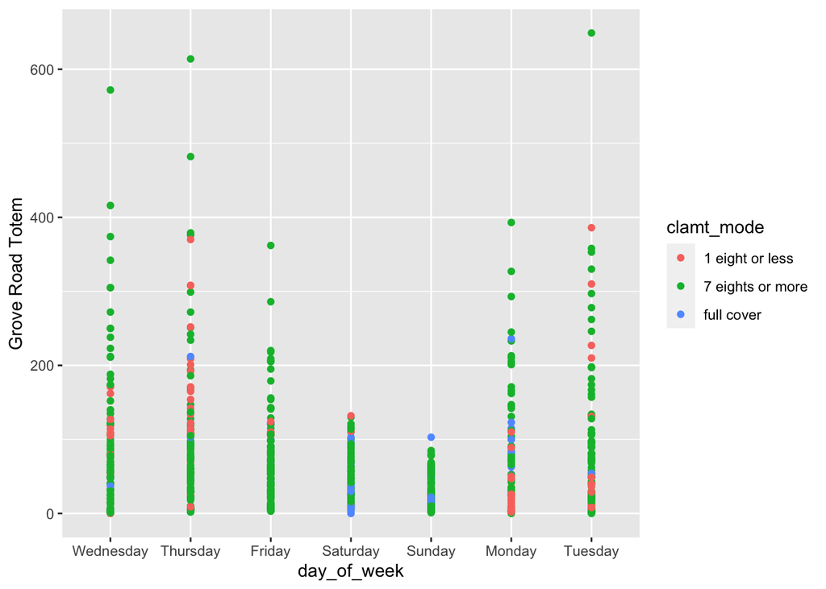

```r
# Map clamt to mode label
db_dec <- db_tib %>%
  filter(month == "December") %>%
  mutate(clamt_mode = case_when(clamt == 0 ~ "absence",
                        clamt == 1 ~ "1 eight or less",
                        clamt %in% 2:7 ~ "7 eights or more",
                        clamt == 8 ~ "full cover",
                        clamt == 9 ~ "foggy", .default = "NA"))

dec_plot <- ggplot(db_dec, aes(y = `Grove Road Totem`, x = day_of_week, color = clamt_mode))
dec_plot + geom_point()
```

## Task 3: Creativity

- Do something interesting with these data! Create two plots or two tables or one plot and one table showing something we have not discovered above already and outline your findings.

```r
# Get mean, median and standard deviation of 'mean hourly wind speed (kt)'
db_tib %>%
  summarise(mean_wind = mean(wdsp), median_wind = median(wdsp), sd_wind = sd(wdsp))
```

```
# A tibble: 1 × 3
  mean_wind median_wind sd_wind
      <dbl>       <dbl>   <dbl>
1      8.96           9    3.93
```

- Mean / Median around 9 and standard deviation is close to 4 overall.
- Lets look closer at this data per month beyond December.

```r
# Extract year variable
db_tib$year <- as.numeric(format(db_tib$Date,'%Y'))

# Get mean, median and standard deviation of 'mean hourly wind speed (kt)' per year and month
db_wind <- db_tib %>%
  group_by(year, month) %>%
  summarise(mean_wind = mean(wdsp), median_wind = median(wdsp), sd_wind = sd(wdsp))
# Sort by standard deviation
db_wind %>% arrange(desc(sd_wind))
```

```
# A tibble: 13 × 5
# Groups:   year [2]
    year month     mean_wind median_wind sd_wind
   <dbl> <ord>         <dbl>       <dbl>   <dbl>
 1  2022 November       9.95         9.5    4.57
 2  2023 April          8.70         8      4.48
 3  2023 January       10.0          9      4.31
 4  2023 March          9.83         9.5    4.08
 5  2022 October        9.64         9      3.99
 6  2023 August         9.07         9      3.83
 7  2023 July           8.93         8      3.75
 8  2022 September      8.66         8      3.70
 9  2022 December       8.60         8      3.55
10  2023 February       9.31         9      3.55
11  2023 June           7.48         7      3.09
12  2023 May            7.38         7      2.89
13  2022 August         6            6     NA
```

- Notice that the greatest standard deviation in mean wind speed was in November 2022.
- However, January 2023 had the highest mean wind speed (only month to hit double digits for abs value).
- I think this is interesting to note that November 22 was more unpredictable but January was in fact windier on average.

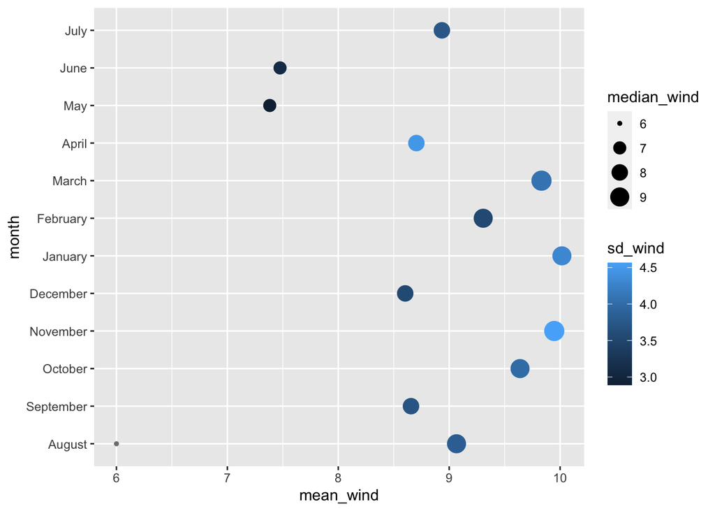

```r
library(ggplot2)

# Creat plot for wind aggregattions
ggplot(db_wind, aes(x = month, y = mean_wind, color = sd_wind, size = median_wind)) +
  geom_point()  +
  coord_flip()
```